# PBMC project

Matteo

2025-06-08

# PART 1

I created a docker by running the terminal in the same folder as my dockerfile. In Dockerfile I punt:

FROM ubuntu:latest

ENV DEBIAN_FRONTEND=noninteractive

RUN apt-get update && apt-get install -y  
curl  
vim  
&& rm -rf /var/lib/apt/lists/*

CMD [“bash”]

Then from the terminal:

docker build -t my-ubuntu-image .

docker run -it my-ubuntu-image

# PART 2

I realized I needed R installed so since it took me too long to install it last time from the ubuntu base image I figured I should pull one with R already installed so:

docker pull r-base:latest

docker run -it –rm r-base:latest R

In this way I could use R inside docker to try installing Seurat and Signac. I tried to install Seurat after apt-get-update and apt-get-install to install dependencies but it was taking too long and it wouldn’t end (waited more than 20min) so again I decided to pull a docker with already Seurat installed. From there I tried to install signac from github. I tried remotes::install_github(“timoast/signac”) but had Warning messages: 1: In install.packages(“Signac”) : installation of package ‘SeuratObject’ had non-zero exit status 2: In install.packages(“Signac”) : installation of package ‘Signac’ had non-zero exit status. I realized I was missing some dependencies so before I installed other packages from Bioconductor like Granges, Matrix and other but when the prompt was asking to update I put Yes and then waited more than 10min and then retried.

# PART 3

## Step 1: Matrix conversion

*• Use the Matrix R package to convert the sparse matrix into a full matrix.*

*• Save the result as a data.table object.*

Loading necessary libraries

```r
library(Seurat)
library(Signac)
```

```r
library(Matrix)
library(data.table)
library(GenomicRanges)
library(ggplot2)
library(rtracklayer)
library(dplyr)
```

Loading and reading files to create the full matrix

```r
matrix_file <- "matrix.mtx.gz"
features_file <- "features.tsv.gz"
barcodes_file <- "barcodes.tsv.gz"
sparse_mat <- readMM(matrix_file)
features <- fread(features_file, header = FALSE)
barcodes <- fread(barcodes_file, header = FALSE)
```

Creating the matrix by using features ENSG gene ID as rows and barcodes as columns. Creating the data table and saving it locally as full_matrix.tsv

```r
rownames(sparse_mat) <- features$V1
colnames(sparse_mat) <- barcodes$V1
full_mat <- as.matrix(sparse_mat)
dt_matrix <- as.data.table(full_mat, keep.rownames = "Gene")
#write.table(dt_matrix, "full_matrix.tsv", sep = "\t", row.names = TRUE) if want to save
```

## Step 2: Split gene expression and ATAC-seq data

*• From the data.table object, separate: o Gene expression data (rows labelled with Ensembl gene IDs, e.g., ENSG00000243485) o ATAC-seq peak data (rows labelled with genomic coordinates, e.g., chrN:NNNN-NNNN)*

```r
gene_expression_dt <- dt_matrix[grepl("^ENSG", Gene)]
atac_peak_dt <- dt_matrix[grepl("^chr[0-9XYM]+:\\d+-\\d+", Gene)]
# missing some rows to reach 117757
# Rows not in genes or peaks
missing_rows <- dt_matrix[!grepl("^ENSG", Gene) & !grepl("^chr[0-9XYM]+:\\d+-\\d+", Gene)]
missing_rows[, Gene] # Check what these missing features are
```

```
##  [1] "KI270728.1:232228-233172"   "KI270728.1:1791270-1791983" "KI270728.1:1792102-1792511"
##  [4] "KI270727.1:52087-52965"     "GL000009.2:113930-114840"   "GL000194.1:27950-28827"
##  [7] "GL000194.1:55758-56625"     "GL000194.1:59549-60358"     "GL000194.1:71564-72412"
## [10] "GL000194.1:72884-73754"     "GL000194.1:101051-101904"   "GL000194.1:114535-115388"
## [13] "GL000205.2:62968-63834"     "GL000205.2:67706-68579"     "GL000205.2:69004-69899"
## [16] "GL000205.2:78245-78981"     "GL000205.2:80805-81701"     "GL000205.2:88677-89482"
## [19] "GL000205.2:140328-141200"   "GL000195.1:30407-31258"     "GL000195.1:32188-33024"
## [22] "GL000195.1:120728-121613"   "GL000219.1:39945-40841"     "GL000219.1:42162-43054"
## [25] "GL000219.1:44807-45592"     "GL000219.1:45722-46375"     "GL000219.1:50731-51770"
## [28] "GL000219.1:90023-90936"     "GL000219.1:92318-93143"     "GL000219.1:99260-100166"
## [31] "GL000219.1:120205-121037"   "GL000219.1:125033-125879"   "GL000219.1:132781-133690"
## [34] "KI270734.1:133560-134405"   "GL000218.1:155567-156493"   "KI270721.1:2090-2985"
## [37] "KI270726.1:27107-28055"     "KI270726.1:41499-42323"     "KI270711.1:7879-8702"
## [40] "KI270711.1:8919-9656"       "KI270711.1:22605-23472"     "KI270713.1:3924-4839"
## [43] "KI270713.1:21448-22354"     "KI270713.1:26202-26986"     "KI270713.1:36937-37838"
```

```r
#If I want to include the missing rows (not referred to standard chromosome):
#atac_peak_dt <- dt_matrix[grepl("^[A-Za-z0-9._]+:\\d+-\\d+", Gene)]
```

## Step 3: Summarize data

*• For each dataset (expression and peaks), compute the column-wise sum to produce: o A single vector of total expression per gene o A single vector of total chromatin accessibility per peak region*

As genes are rows, I sums the rows of my gene_expression_dt except the first one (which containes the barcodes). Same for accessibility. I also attach the names of the genes to the vector components.

```r
# Total expression per gene
total_expression <- rowSums(gene_expression_dt[, -1, with = FALSE])
# Total chromatin accessibility per peak region
total_accessibility <- rowSums(atac_peak_dt[, -1, with = FALSE])
# Attach names
names(total_expression) <- gene_expression_dt$Gene
names(total_accessibility) <- atac_peak_dt$Gene
```

## Step 4: Create Genomic Ranges

*• Convert both the summarized gene expression and peak data into GenomicRanges objects. • Add the summarized data as metadata to their respective GenomicRanges.*

To create the GRanges object for the peak data I created peak_features which contain all the information of the genes where the third column is peaks (the ATAC peaks). In this way, I already had start and ending position in the features columns. I couldn’t save the result locally because it was taking too much time (do not know why). I added total_accessibility vector as a metadata.

I have done the same for gene expression, but the GRanges was giving me an error because some columns of the features where NA so I added it and then created the ranges. I also added Gene ID, symbol and total_expression as metadata.

```r
peak_features <- features[grepl("^chr[0-9XYM]+:\\d+-\\d+", features$V1)]
# Create GRanges object for accessibility
peak_gr <- GRanges(
  seqnames = peak_features$V4,
  ranges = IRanges(start = as.numeric(peak_features$V5),
                   end = as.numeric(peak_features$V6)),
  accessibility = total_accessibility
)
peak_gr
```

```
## GRanges object with 81111 ranges and 1 metadata column:
##           seqnames            ranges strand | accessibility
##              <Rle>         <IRanges>  <Rle> |     <numeric>
##       [1]     chr1        9782-10672      * |            46
##       [2]     chr1     180547-181446      * |            83
##       [3]     chr1     191121-191998      * |            20
##       [4]     chr1     267553-268447      * |            74
##       [5]     chr1     270906-271782      * |            26
##       ...      ...               ...    ... .           ...
##   [81107]     chrY 11322280-11322995      * |            23
##   [81108]     chrY 11323118-11323755      * |            14
##   [81109]     chrY 11332864-11333512      * |            52
##   [81110]     chrY 11333632-11334281      * |            46
##   [81111]     chrY 56846844-56847757      * |            26
##   -------
##   seqinfo: 24 sequences from an unspecified genome; no seqlengths
```

```r
#saveRDS(peak_gr, "peak_gr.rds") takes too long!

gene_features <- features[features$V3 == "Gene Expression"]
#add "chr" because I have some NA in V4
gene_features$V4 <- as.character(gene_features$V4)
gene_features$V4 <- ifelse(grepl("^chr", gene_features$V4),
                           gene_features$V4, paste0("chr", gene_features$V4))
# Create GRanges object for gene expression
gene_gr <- GRanges(
  seqnames = gene_features$V4,
  ranges = IRanges(start = as.numeric(gene_features$V5),
                   end = as.numeric(gene_features$V6)),
  strand = "*",
  gene_id = gene_features$V1,
  gene_symbol = gene_features$V2,
  expression = total_expression
)
gene_gr
```

```
## GRanges object with 36601 ranges and 3 metadata columns:
##                seqnames          ranges strand |         gene_id gene_symbol expression
##                   <Rle>       <IRanges>  <Rle> |     <character> <character>  <numeric>
##       [1]          chr1     29553-30267      * | ENSG00000243485 MIR1302-2HG          0
##       [2]          chr1     36080-36081      * | ENSG00000237613     FAM138A          0
##       [3]          chr1     65418-69055      * | ENSG00000186092       OR4F5          0
##       [4]          chr1   120931-133723      * | ENSG00000238009  AL627309.1         16
##       [5]          chr1     91104-91105      * | ENSG00000239945  AL627309.3          1
##       ...           ...             ...    ... .             ...         ...        ...
##   [36597] chrKI270728.1 1270983-1270984      * | ENSG00000277836  AC141272.1          0
##   [36598] chrKI270731.1     13000-13001      * | ENSG00000278633  AC023491.2          0
##   [36599] chrKI270734.1     72410-72411      * | ENSG00000276017  AC007325.1          2
##   [36600] chrKI270734.1   131493-131494      * | ENSG00000278817  AC007325.4          8
##   [36601] chrKI270734.1   161749-161852      * | ENSG00000277196  AC007325.2          0
##   -------
##   seqinfo: 40 sequences from an unspecified genome; no seqlengths
```

```r
#saveRDS(gene_gr, "gene_gr.rds") too long!
```

## Step 5: Gene annotation for ATACsep data

*• Using the annotation file Homo_sapiens.GRCh38.114.gtf.gz: o Create a GenomicRanges object only for protein-coding genes and only for gene features.*

*o Remap the ATAC-seq GenomicRanges to this object and attach the summarized peak data from step 4.*

I imported the gtf files and then took only the protein coding genes from gene_biotype column. Next, to find overlaps, I added “chr” in the seqlevels of gtf protein coding genes because otherwise it was not comparable with my peak_gr. I understood that my ATAC seq peak (peak_gr) need to be mapped to understand which gene they are referred to. So I took the indexes and created a data.table with peaks and genes info. Finally I sum the overlapping gene ID to obtain peak_summary.

```r
gtf <- import("Homo_sapiens.GRCh38.114.gtf.gz")
gtf_genes <- gtf[gtf$type == "gene" & gtf$gene_biotype == "protein_coding"]
# Find overlaps
#missing the name chr on gtf so I need to add it
seqlevels(gtf_genes) <- paste0("chr", seqlevels(gtf_genes))

#I use my peak_gr as query to gtf_genes
overlaps <- findOverlaps(peak_gr, gtf_genes)

# Get indices to extract which peak overlaps which gene:
peak_idx <- queryHits(overlaps)
gene_idx <- subjectHits(overlaps)
# Create a data.table with gene and peak info
dt_gene_peak <- data.table(
  gene_id = gtf_genes$gene_id[gene_idx],
  accessibility = mcols(peak_gr)$accessibility[peak_idx]
)
# Sum accessibility per gene
peak_summary <- dt_gene_peak[, .(total_peak_accessibility = sum(accessibility)), by = gene_id]
peak_summary
```

```
##                gene_id total_peak_accessibility
##                 <char>                    <num>
##     1: ENSG00000187634                      804
##     2: ENSG00000188976                     1835
##     3: ENSG00000187961                      774
##     4: ENSG00000187583                     1110
##     5: ENSG00000187642                      372
##    ---
## 16136: ENSG00000155961                      503
## 16137: ENSG00000185973                      477
## 16138: ENSG00000168939                      477
## 16139: ENSG00000124333                      777
## 16140: ENSG00000124334                       74
```

```r
#fwrite(peak_summary, file = "peak_summary.csv")

# Match peak_summary to gtf_genes by gene_id
match_idx <- match(gtf_genes$gene_id, peak_summary$gene_id)
# Create a new metadata column
mcols(gtf_genes)$total_peak_accessibility <- peak_summary$total_peak_accessibility[match_idx]
# Optional: set NA to 0 for genes with no overlapping peaks
mcols(gtf_genes)$total_peak_accessibility[is.na(mcols(gtf_genes)$total_peak_accessibility)] <- 0
summary(gtf_genes)
```

```
## [1] "GRanges object with 20120 ranges and 23 metadata columns"
```

## Step 6: Finalize expression data

*• Subset the expression GenomicRanges, step 4, to include only protein-coding genes.*

*• Add gene symbol identifiers to the object.*

gtf_genes contains only the protein coding so I create protein_coding_ids with the gene_id column from gtf_genes. Now I create gene_gr_pc (GRanges from gene_gr subsetted for protein coding), taking only the gene id which are in protein_coding_ids. To add the gene_id and symbol I used a lookup table to match symbol and id.

```r
protein_coding_ids <- gtf_genes$gene_id
# Keep only entries in gene_gr whose gene_id is protein-coding
gene_gr_pc <- gene_gr[mcols(gene_gr)$gene_id %in% protein_coding_ids]
# Create a lookup table from GTF: gene_id -> gene_name
gtf_lookup <- data.table(
  gene_id = gtf_genes$gene_id,
  gene_symbol = gtf_genes$gene_name
)
# Match by gene_id
lookup_idx <- match(mcols(gene_gr_pc)$gene_id, gtf_lookup$gene_id)
# Add gene symbols to metadata
mcols(gene_gr_pc)$gene_symbol <- gtf_lookup$gene_symbol[lookup_idx]
gene_gr_pc
```

```
## GRanges object with 19252 ranges and 3 metadata columns:
##                seqnames          ranges strand |         gene_id gene_symbol expression
##                   <Rle>       <IRanges>  <Rle> |     <character> <character>  <numeric>
##       [1]          chr1     65418-69055      * | ENSG00000186092       OR4F5          0
##       [2]          chr1   451696-451697      * | ENSG00000284733      OR4F29          0
##       [3]          chr1   686672-686673      * | ENSG00000284662      OR4F16          0
##       [4]          chr1   925730-925741      * | ENSG00000187634      SAMD11          4
##       [5]          chr1   959255-959256      * | ENSG00000188976       NOC2L        384
##       ...           ...             ...    ... .             ...         ...        ...
##   [19248] chrKI270728.1 1270983-1270984      * | ENSG00000277836        <NA>          0
##   [19249] chrKI270731.1     13000-13001      * | ENSG00000278633        <NA>          0
##   [19250] chrKI270734.1     72410-72411      * | ENSG00000276017        <NA>          2
##   [19251] chrKI270734.1   131493-131494      * | ENSG00000278817        <NA>          8
##   [19252] chrKI270734.1   161749-161852      * | ENSG00000277196        <NA>          0
##   -------
##   seqinfo: 40 sequences from an unspecified genome; no seqlengths
```

## Step 7: Data normalization and Integration

*• Normalize both expression and ATAC-seq data using CPM: o Divide each column by the column sum, multiply by 10^6, add a pseudo-count of 1, and apply log2. • Merge expression and ATAC data based on common genes. • Provide a summary table of the number of ATAC peaks that could not be merged and a plot of peak intensity distribution chromosome by chromosome. Provide a summary table of the genes which do not show association with ATAC peaks and plot their expression distribution chromosome by chromosome*

From peak_gr I could already made a plot of the accessibility for chromosomes.

As I need to provide a summary table of the number of peaks that could not be merged I used unique and setdiff to find them and then created the unmerged_summary that i also plotted.

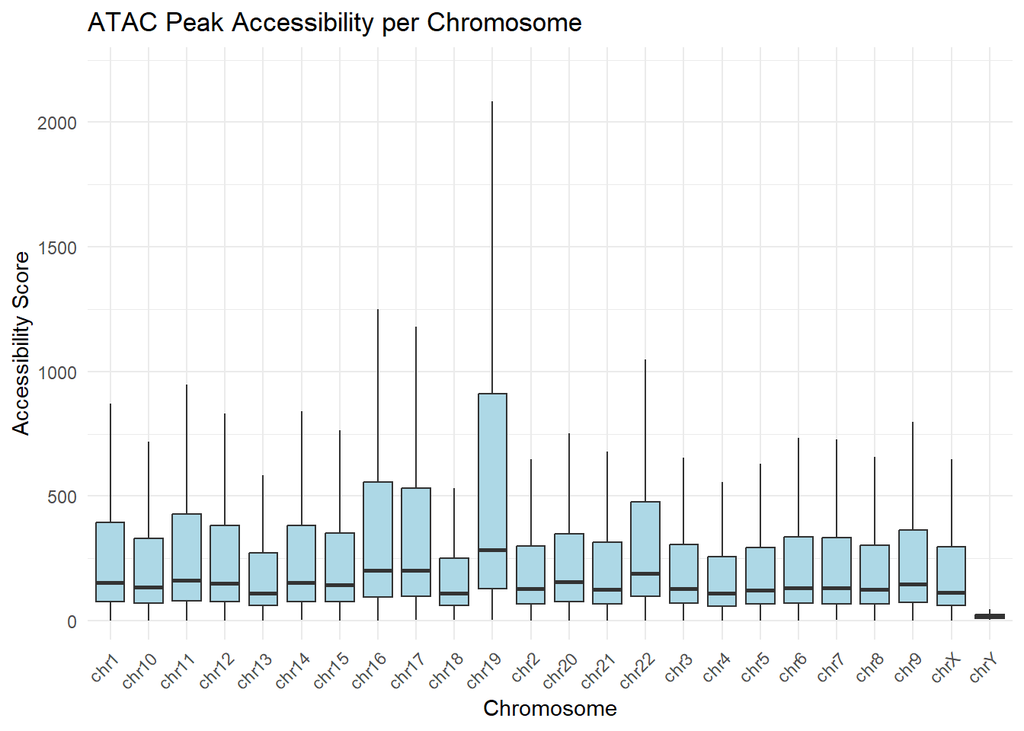

```r
# Extract matrix: assume gene_expression_dt includes genes as rows, samples as columns
expr_mat <- as.matrix(gene_expression_dt[, -1, with = FALSE])  # remove gene ID column
# CPM normalization
expr_cpm <- log2((t(t(expr_mat) / colSums(expr_mat)) * 1e6) + 1)
# Assume atac_peak_dt is similar: peaks as rows, columns as cells/samples
atac_mat <- as.matrix(atac_peak_dt[, -1, with = FALSE])
# CPM normalization
atac_cpm <- log2((t(t(atac_mat) / colSums(atac_mat)) * 1e6) + 1)

# Create data.table for merging
expr_dt <- data.table(
  gene_id = mcols(gene_gr_pc)$gene_id,
  expr_cpm = mcols(gene_gr_pc)$expression,
  chr = as.character(seqnames(gene_gr_pc))
)

atac_dt <- data.table(
  gene_id = gtf_genes$gene_id,
  atac_cpm = mcols(gtf_genes)$total_peak_accessibility
)

# Merge by gene_id
merged_dt <- merge(expr_dt, atac_dt, by = "gene_id",all=TRUE)

#from the peak gr I can already create total peaks (accessibility) per chromosomes
peak_dt <- as.data.table(peak_gr)
peak_dt[, accessibility := mcols(peak_gr)$accessibility]
peak_dt[, chr := as.character(seqnames)]
# Boxplot of total accessibility per chromosome from atac
p <- ggplot(peak_dt, aes(x = chr, y = accessibility)) +
  geom_boxplot(outlier.shape = NA, fill = "lightblue") +
  coord_cartesian(ylim = quantile(peak_dt$accessibility, c(0.05, 0.95), na.rm = TRUE)) +
  theme_minimal() +
  labs(title = "ATAC Peak Accessibility per Chromosome",
       x = "Chromosome", y = "Accessibility Score") +
  theme(axis.text.x = element_text(angle = 45, hjust = 1))
p
```

```r
#provide a summary table of the number of peaks that could not be merged
used_peak_ids <- unique(queryHits(overlaps))
unmerged_peak_ids <- setdiff(seq_along(peak_gr), used_peak_ids)
unmerged_peaks_dt <- as.data.table(peak_gr[unmerged_peak_ids])
unmerged_summary <- unmerged_peaks_dt[, .N, by = seqnames]
unmerged_summary
```

```
##     seqnames     N
##       <fctr> <int>
##  1:     chr1  3038
##  2:    chr10  1381
##  3:    chr11  1304
##  4:    chr12  1469
##  5:    chr13   740
##  6:    chr14  1098
##  7:    chr15   889
##  8:    chr16   807
##  9:    chr17  1404
## 10:    chr18   533
## 11:    chr19   989
## 12:     chr2  2444
## 13:    chr20   903
## 14:    chr21   369
## 15:    chr22   639
## 16:     chr3  1636
## 17:     chr4  1092
## 18:     chr5  1520
## 19:     chr6  2007
## 20:     chr7  1361
## 21:     chr8  1283
## 22:     chr9  1243
## 23:     chrX   879
## 24:     chrY    14
##     seqnames     N
```

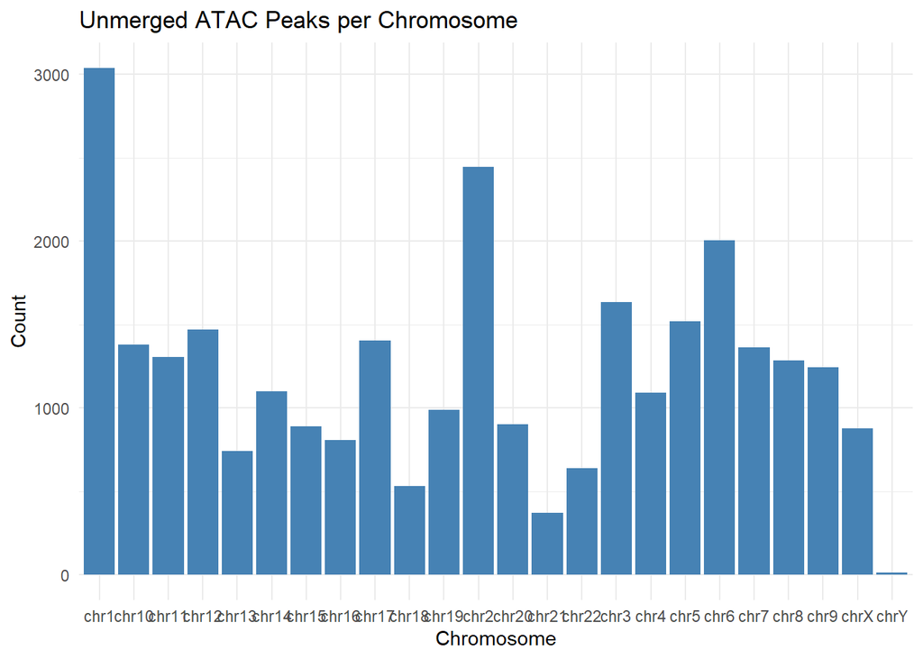

```r
#fwrite(unmerged_summary, "unmerged_summary.tsv")
p1<-ggplot(unmerged_summary, aes(x = seqnames, y = N)) +
    geom_bar(stat = "identity", fill = "steelblue") +
    theme_minimal() +
    labs(title = "Unmerged ATAC Peaks per Chromosome", x = "Chromosome", y = "Count")
p1 #there are also all the other non chromosome which I took from peaks
```

```r
#ggsave("unmerged_peaks.png", plot = p1, width = 10, height = 8, dpi = 300, bg = "white") to save the plot
```

## Step 8: Visualization

*• Generate a scatter plot using ggplot2: o X-axis: log-transformed expression CPM o Y-axis: log-transformed ATAC CPM • If the plot is too much busy of data divide the plot in the 24 chromosomes*

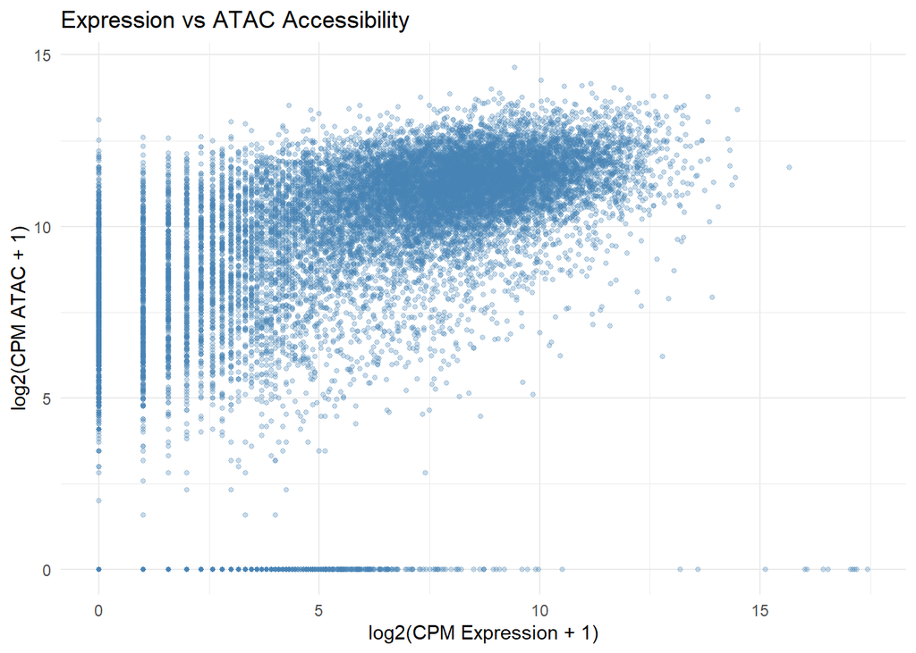

```r
#LOG2 transform
merged_dt[, expr_log := log2(expr_cpm + 1)]
merged_dt[, atac_log := log2(atac_cpm + 1)]
p2 <- ggplot(merged_dt, aes(x = expr_log, y = atac_log)) +
  geom_point(alpha = 0.3, color = "steelblue", size = 1) +
  theme_minimal() +
  labs(title = "Expression vs ATAC Accessibility",
       x = "log2(CPM Expression + 1)",
       y = "log2(CPM ATAC + 1)")
p2 #crowded plot to split in chromosome
```

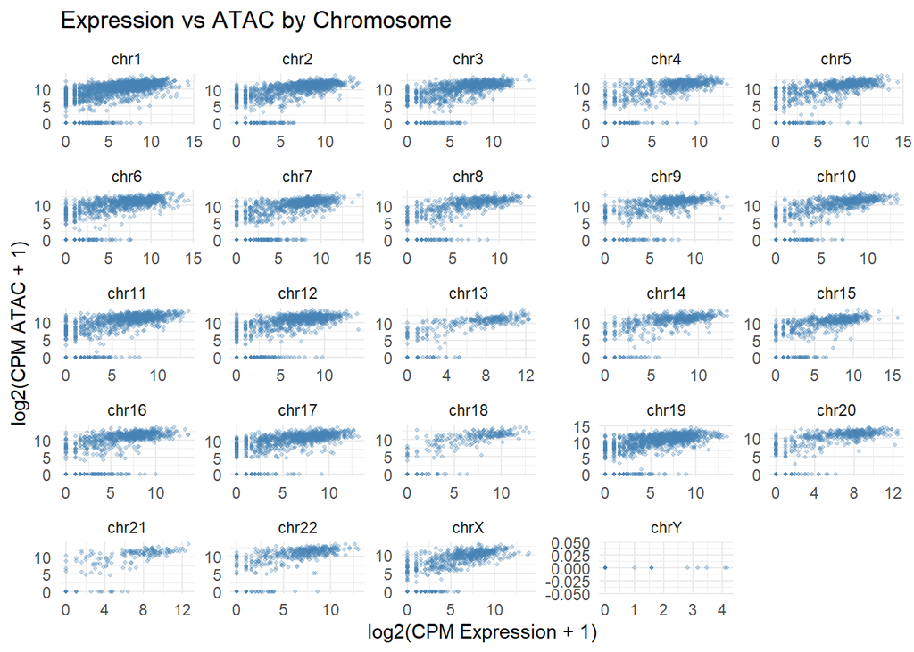

```r
# Filter to 24 chromosomes only
merged_dt_chr <- merged_dt[chr %in% paste0("chr", c(1:22, "X", "Y"))]
# Order chromosomes
merged_dt_chr[, chr := factor(chr, levels = paste0("chr", c(1:22, "X", "Y")))]

# Plot splitted chr
p3<-ggplot(merged_dt_chr, aes(x = expr_log, y = atac_log)) +
  geom_point(alpha = 0.3, color = "steelblue", size = 0.8) +
  theme_minimal() +
  facet_wrap(~chr, scales = "free") +
  labs(title = "Expression vs ATAC by Chromosome",
       x = "log2(CPM Expression + 1)",
       y = "log2(CPM ATAC + 1)")
p3
```

```r
#ggsave("expression_vs_atac_by_chr.png", plot = p3, width = 10, height = 8, dpi = 300, bg = "white") if want to save
```

# PART 4

rmarkdown::render(“your_file.Rmd”)